# Desafio_11

Author

Amanda Cedro

# DESAFIO 11

```python
import polars as pl        # Manipulação e análise de dados (substitui o pandas)
import matplotlib.pyplot as plt  # Visualizações (será útil nas próximas questões)
```

## Questão 1:

Utilizando o arquivo renda_adulta.csv e sabendo que ele não possui cabeçalho, faça a importação do banco de dados utilizando os nomes das colunas conforme apresentado acima e na sequência ali indicada. No momento da importação do arquivo, você deve, também, indicar os tipos de cada uma das colunas. Utilize o fato de que o símbolo ? representa valores faltantes.

```python
colunas = [
    "age", "workclass", "fnlwgt", "education", "education-num",
    "marital-status", "occupation", "relationship", "race", "sex",
    "capital-gain", "capital-loss", "hours-per-week",
    "native-country", "income"
]
tipos = {
    "age": pl.Int64,
    "workclass": pl.Categorical,
    "fnlwgt": pl.Int64,
    "education": pl.Categorical,
    "education-num": pl.Int64,
    "marital-status": pl.Categorical,
    "occupation": pl.Categorical,
    "relationship": pl.Categorical,
    "race": pl.Categorical,
    "sex": pl.Categorical,
    "capital-gain": pl.Int64,
    "capital-loss": pl.Int64,
    "hours-per-week": pl.Int64,
    "native-country": pl.Categorical,
    "income": pl.Categorical
}
# Importar o arquivo compactado
df = pl.read_csv(
    "dados/renda_adulta.csv.gz",  # caminho da pasta "dados"
    has_header=False,  # arquivo não possui cabeçalho
    new_columns=colunas,          # define os nomes das colunas
    schema_overrides=tipos,       # define os tipos de cada coluna
    null_values="?"               # substitui "?" por nulos
)
df.head() #Verifica a importação
```

shape: (5, 15)

| age i64 | workclass cat | fnlwgt i64 | education cat | education-num i64 | marital-status cat | occupation cat | relationship cat | race cat | sex cat | capital-gain i64 | capital-loss i64 | hours-per-week i64 | native-country cat | income cat |
| --- | --- | --- | --- | --- | --- | --- | --- | --- | --- | --- | --- | --- | --- | --- |
| 39 | "State-gov" | 77516 | "Bachelors" | 13 | "Never-married" | "Adm-clerical" | "Not-in-family" | "White" | "Male" | 2174 | 0 | 40 | "United-States" | "<=50K" |
| 50 | "Self-emp-not-inc" | 83311 | "Bachelors" | 13 | "Married-civ-spouse" | "Exec-managerial" | "Husband" | "White" | "Male" | 0 | 0 | 13 | "United-States" | "<=50K" |
| 38 | "Private" | 215646 | "HS-grad" | 9 | "Divorced" | "Handlers-cleaners" | "Not-in-family" | "White" | "Male" | 0 | 0 | 40 | "United-States" | "<=50K" |
| 53 | "Private" | 234721 | "11th" | 7 | "Married-civ-spouse" | "Handlers-cleaners" | "Husband" | "Black" | "Male" | 0 | 0 | 40 | "United-States" | "<=50K" |
| 28 | "Private" | 338409 | "Bachelors" | 13 | "Married-civ-spouse" | "Prof-specialty" | "Wife" | "Black" | "Female" | 0 | 0 | 40 | "Cuba" | "<=50K" |

```python
df.schema #Confere a tipagem
```

```
Schema({'age': Int64, 'workclass': Categorical, 'fnlwgt': Int64, 'education': Categorical, 'education-num': Int64, 'marital-status': Categorical, 'occupation': Categorical, 'relationship': Categorical, 'race': Categorical, 'sex': Categorical, 'capital-gain': Int64, 'capital-loss': Int64, 'hours-per-…
```

## Questão 2:

Apresente os tipos de cada uma das coluna.

```python
# Exibir o esquema (nomes e tipos das colunas)
df.schema
```

```
Schema({'age': Int64, 'workclass': Categorical, 'fnlwgt': Int64, 'education': Categorical, 'education-num': Int64, 'marital-status': Categorical, 'occupation': Categorical, 'relationship': Categorical, 'race': Categorical, 'sex': Categorical, 'capital-gain': Int64, 'capital-loss': Int64, 'hours-per-…
```

```python
# Converter o schema em um DataFrame para visualizar melhor
pl.DataFrame({
    "Coluna": list(df.schema.keys()),
    "Tipo": [str(t) for t in df.schema.values()]
})
```

shape: (15, 2)

| Coluna str | Tipo str |
| --- | --- |
| "age" | "Int64" |
| "workclass" | "Categorical" |
| "fnlwgt" | "Int64" |
| "education" | "Categorical" |
| "education-num" | "Int64" |
| … | … |
| "capital-gain" | "Int64" |
| "capital-loss" | "Int64" |
| "hours-per-week" | "Int64" |
| "native-country" | "Categorical" |
| "income" | "Categorical" |

## Questão 3:

Apresente as dimensões da tabela de dados.

```python
# Ver dimensões da tabela
linhas, colunas = df.shape
print(f"O DataFrame possui {linhas} linhas e {colunas} colunas.")
```

```
O DataFrame possui 32561 linhas e 15 colunas.
```

```python
df.shape #Outra maneira apresentada como: (linhas, colunas)
```

```
(32561, 15)
```

## Questão 4:

Quantas pessoas recebem acima de $50.000 e quantas pessoas recebem abaixo deste limiar?

```python
# Contar quantas pessoas pertencem a cada categoria de renda
contagem_renda = (
    df
    .group_by("income")       # agrupa pela variável 'income'
    .agg(pl.len())          # conta o número de linhas em cada grupo
    .sort("income")           # ordena para facilitar a leitura
)

contagem_renda
```

shape: (2, 2)

| income cat | len u32 |
| --- | --- |
| "<=50K" | 24720 |
| ">50K" | 7841 |

## Questão 5:

Crie um objeto chamado renda_longo, no qual você transforma as colunas capital-gain e capital-loss (formato wide) para formato longo. Os valores destas variáveis devem ser armazenados numa nova coluna chamada Valor e os tipos de valores (gain e loss) devem ser armazenados numa coluna chamada tipo.

```python
# Criar o objeto 'renda_longo' transformando as colunas capital-gain e capital-loss
renda_longo = df.unpivot(
    index=[col for col in df.columns if col not in ["capital-gain", "capital-loss"]],
    on=["capital-gain", "capital-loss"],
    variable_name="tipo",
    value_name="Valor"
)

# Ajustar os nomes de tipo para apenas 'gain' e 'loss'
renda_longo = renda_longo.with_columns(
    pl.col("tipo").str.replace("capital-", "")   # remove o prefixo 'capital-'
)
renda_longo.head()
```

shape: (5, 15)

| age i64 | workclass cat | fnlwgt i64 | education cat | education-num i64 | marital-status cat | occupation cat | relationship cat | race cat | sex cat | hours-per-week i64 | native-country cat | income cat | tipo str | Valor i64 |
| --- | --- | --- | --- | --- | --- | --- | --- | --- | --- | --- | --- | --- | --- | --- |
| 39 | "State-gov" | 77516 | "Bachelors" | 13 | "Never-married" | "Adm-clerical" | "Not-in-family" | "White" | "Male" | 40 | "United-States" | "<=50K" | "gain" | 2174 |
| 50 | "Self-emp-not-inc" | 83311 | "Bachelors" | 13 | "Married-civ-spouse" | "Exec-managerial" | "Husband" | "White" | "Male" | 13 | "United-States" | "<=50K" | "gain" | 0 |
| 38 | "Private" | 215646 | "HS-grad" | 9 | "Divorced" | "Handlers-cleaners" | "Not-in-family" | "White" | "Male" | 40 | "United-States" | "<=50K" | "gain" | 0 |
| 53 | "Private" | 234721 | "11th" | 7 | "Married-civ-spouse" | "Handlers-cleaners" | "Husband" | "Black" | "Male" | 40 | "United-States" | "<=50K" | "gain" | 0 |
| 28 | "Private" | 338409 | "Bachelors" | 13 | "Married-civ-spouse" | "Prof-specialty" | "Wife" | "Black" | "Female" | 40 | "Cuba" | "<=50K" | "gain" | 0 |

## Questão 6:

Quais são as médias de horas trabalhadas por classe salarial?

```python
medias_horas_renda = (
    df.group_by("income")  # Agrupa por classe salarial
    .agg(pl.col("hours-per-week").mean().alias("media_horas_semana")  # Calcula a média de horas por semana
    ).sort("income")  # Ordena por classe salarial
)

print("Médias de horas trabalhadas por semana por classe salarial:")
```

```
Médias de horas trabalhadas por semana por classe salarial:
```

```python
print(medias_horas_renda)
```

```
shape: (2, 2)
┌────────┬────────────────────┐
│ income ┆ media_horas_semana │
│ ---    ┆ ---                │
│ cat    ┆ f64                │
╞════════╪════════════════════╡
│ <=50K  ┆ 38.84021           │
│ >50K   ┆ 45.473026          │
└────────┴────────────────────┘
```

## Questão 7:

Se cada linha representa uma pessoa, quantas pessoas foram amostradas em cada profissão?

```python
pessoas_por_profissao = (
    df.group_by("occupation")  # Agrupa por profissão
    .agg(pl.len().alias("quantidade_pessoas")  # Conta o número de pessoas em cada profissão
    )
    .sort("quantidade_pessoas", descending=True)  # Ordena da maior para a menor quantidade
)

print("Quantidade de pessoas amostradas em cada profissão:")
```

```
Quantidade de pessoas amostradas em cada profissão:
```

```python
print(pessoas_por_profissao)
```

```
shape: (15, 2)
┌─────────────────┬────────────────────┐
│ occupation      ┆ quantidade_pessoas │
│ ---             ┆ ---                │
│ cat             ┆ u32                │
╞═════════════════╪════════════════════╡
│ Prof-specialty  ┆ 4140               │
│ Craft-repair    ┆ 4099               │
│ Exec-managerial ┆ 4066               │
│ Adm-clerical    ┆ 3770               │
│ Sales           ┆ 3650               │
│ …               ┆ …                  │
│ Farming-fishing ┆ 994                │
│ Tech-support    ┆ 928                │
│ Protective-serv ┆ 649                │
│ Priv-house-serv ┆ 149                │
│ Armed-Forces    ┆ 9                  │
└─────────────────┴────────────────────┘
```

## Questão 8:

Crie um gráfico de barras que apresente o número médio de horas trabalhadas semanalmente em função do nível salarial.

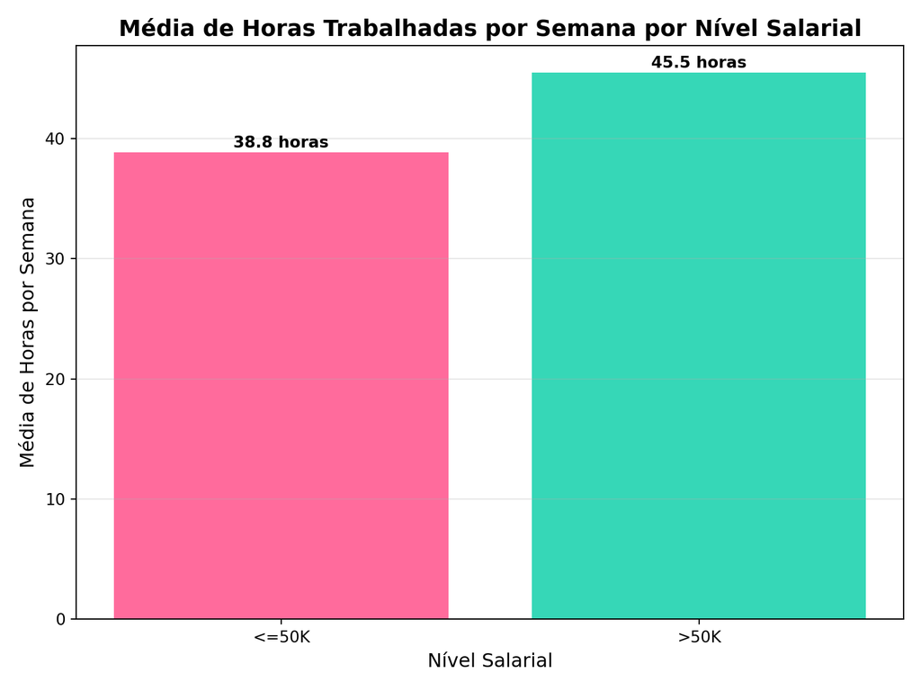

```python
# Primeiro, vamos preparar os dados para o gráfico
dados_grafico = (df.group_by("income").agg(pl.col("hours-per-week").mean().alias("media_horas")).sort("income"))

# Converter para pandas para facilitar a plotagem com matplotlib
graph_pandas = dados_grafico.to_pandas()

# Criar o gráfico de barras
plt.figure(figsize=(8, 6))
bars = plt.bar(graph_pandas['income'], graph_pandas['media_horas'],
               color=['#FF6B9C', '#36D7B7'])

# Personalizar o gráfico
plt.title('Média de Horas Trabalhadas por Semana por Nível Salarial', fontsize=14, fontweight='bold')
plt.xlabel('Nível Salarial', fontsize=12)
plt.ylabel('Média de Horas por Semana', fontsize=12)
plt.grid(axis='y', alpha=0.3)

# Adicionar os valores nas barras
for bar in bars:
    height = bar.get_height()
    plt.text(bar.get_x() + bar.get_width()/2., height + 0.1,
             f'{height:.1f} horas',
             ha='center', va='bottom', fontweight='bold')

plt.tight_layout()
plt.show()
```

```python
# Mostrar os dados numéricos também
print("Dados utilizados no gráfico:")
```

```
Dados utilizados no gráfico:
```

```python
print(dados_grafico)
```

```
shape: (2, 2)
┌────────┬─────────────┐
│ income ┆ media_horas │
│ ---    ┆ ---         │
│ cat    ┆ f64         │
╞════════╪═════════════╡
│ <=50K  ┆ 38.84021    │
│ >50K   ┆ 45.473026   │
└────────┴─────────────┘
```

## Questão 9:

**Desafio**: existe alguma evidência de discriminação salarial entre gêneros biológicos?

```python
# Contagem de homens e mulheres por classe salarial
genero_renda = (df.group_by(["sex", "income"]).agg(pl.len().alias("n_pessoas")).sort(["sex", "income"]))
genero_renda
```

shape: (4, 3)

| sex cat | income cat | n_pessoas u32 |
| --- | --- | --- |
| "Female" | "<=50K" | 9592 |
| "Female" | ">50K" | 1179 |
| "Male" | "<=50K" | 15128 |
| "Male" | ">50K" | 6662 |

```python
# Total de cada gênero
total_genero = df.group_by("sex").agg(pl.len().alias("total"))
# Pessoas com >50K por gênero
acima_50k = df.filter(pl.col("income")==">50K").group_by("sex").agg(pl.len().alias("acima_50k"))

# Juntar e calcular proporção
discriminacao = total_genero.join(acima_50k, on="sex")
discriminacao = discriminacao.with_columns(
    (pl.col("acima_50k") / pl.col("total") * 100).alias("perc_acima_50k")
)

discriminacao
```

shape: (2, 4)

| sex cat | total u32 | acima_50k u32 | perc_acima_50k f64 |
| --- | --- | --- | --- |
| "Female" | 10771 | 1179 | 10.946059 |
| "Male" | 21790 | 6662 | 30.573658 |

```python
# Converter para Pandas
discriminacao_pd = discriminacao.to_pandas()

# Gráfico de barras
plt.figure(figsize=(6,4))
bars = plt.bar(discriminacao_pd["sex"], discriminacao_pd["perc_acima_50k"],
               color=['#FF6B9C', '#36D7B7'], linewidth=1.2)
plt.title("Proporção de pessoas ganhando >50K por gênero", fontsize=16, fontweight='bold')
plt.ylabel("Percentual (%)", fontsize=12)
plt.xlabel("Gênero", fontsize=12)
plt.ylim(0, 40)
```

```
(0.0, 40.0)
```

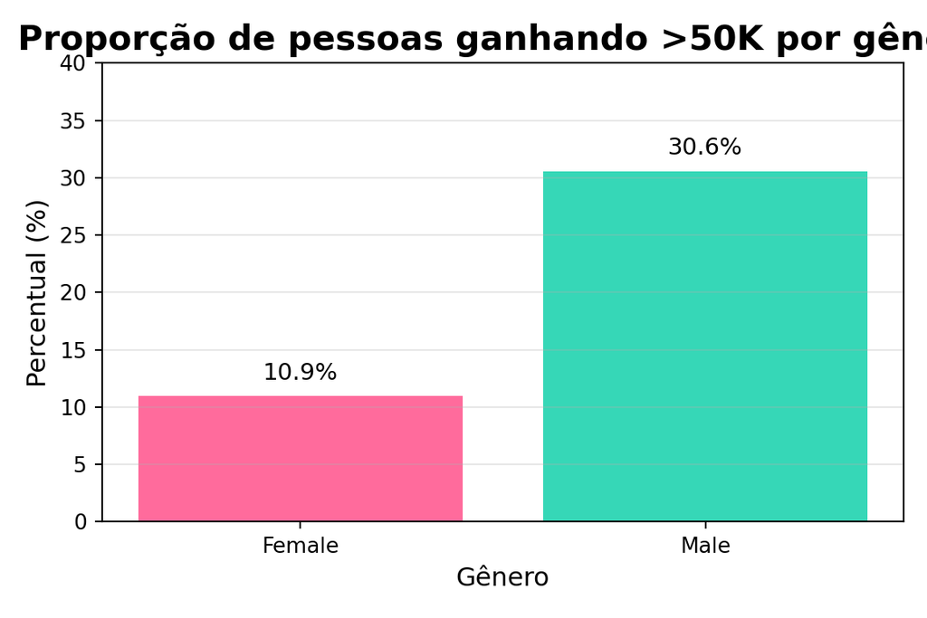

```python
plt.grid(axis='y', alpha=0.3)

# Adicionar os valores em cima das barras
for bar in bars:
    altura = bar.get_height()
    plt.text(
        bar.get_x() + bar.get_width()/2,  # posição x (centro da barra)
        altura + 1,                       # posição y (um pouco acima da barra)
        f'{altura:.1f}%',                 # texto (ex.: 10.4%)
        ha='center',                       # centralizar horizontalmente
        va='bottom',
        fontsize=11
    )

plt.tight_layout()
plt.show()
```

**ANÁLISE ESTATÍSTICA SIMPLES:**

- **Total Masculino:** 21790
- **Total Feminino:** 10771
- **Alta renda Masculino:** 6662 (30.57%)
- **Alta renda Feminino:** 1179 (10.95%)
- **Diferença percentual:** 19.63 pontos percentuais

Portanto, temos dados mostrando que homens têm 2.79x mais chances de ter alta renda do que mulheres, na qual a diferença percentual de entre os dois sexos é de 19,63 pontos. Isso evidencia uma provável discriminação salarial entre gêneros biológicos.

## Data e hora do html:

```r
# Salvando a data e o horário em que o html foi gerado
Sys.time()
```

```
[1] "2025-10-07 11:31:36 -03"
```